# Methods 4 – Portfolio Assignment 2

```r
pacman::p_load(tidyverse, rethinking, dagitty,GGally)
```

- *Type:* Group assignment
- *Due:* 3 April 2022, 23:59

Hello CogSci's :)

In this portfolio, you are asked to do four tasks:

- Make a DAG for something

- Simulate data that fits the DAG

- Use linear models to confirm that the DAG fits the data

- Mess it up.

Each of the four tasks have some sub-steps.  
Report briefly what you find, for example in a markdown document, for example called report.md so that the poor TA can easily get an overview before looking in your code :)

Then you can also make a (brief!) explanation of the phenomenon you are DAGGIN, simulating and modelling.

Looking forward !

## Task 1: The DAG

- **Make a DAG** for the phenomenon. Make it medium complicated: that means, make sure there are some different kinds of relations (see next step). Change it if you don't get anything interesting for the next steps.  
**Draw it** somehow (on paper, in R, laser engraved in diamond).  
**Code it** in dagitty (this is a nice tool: http://dagitty.net/dags.html )

- Find **elemental forms of variable relations** in the DAG (i.e., forks, pipes, colliders, and their descendants).

- Find out **what variables to include (and not include)** in a multiple linear regression to avoid 'back door' (AKA non-causal) paths. Do this first with your eyes and your mind. Then you can use dagitty's function `adjustmentSets()`.

- Find out which **conditional independencies** the DAG implies. First with the mind, then with daggity's function `impliedConditionalIndependencies()`.

- Find the full list of **Markov equivalent** DAGS. Use daggity's function `equivalentGraphs()`.

### Making the DAG

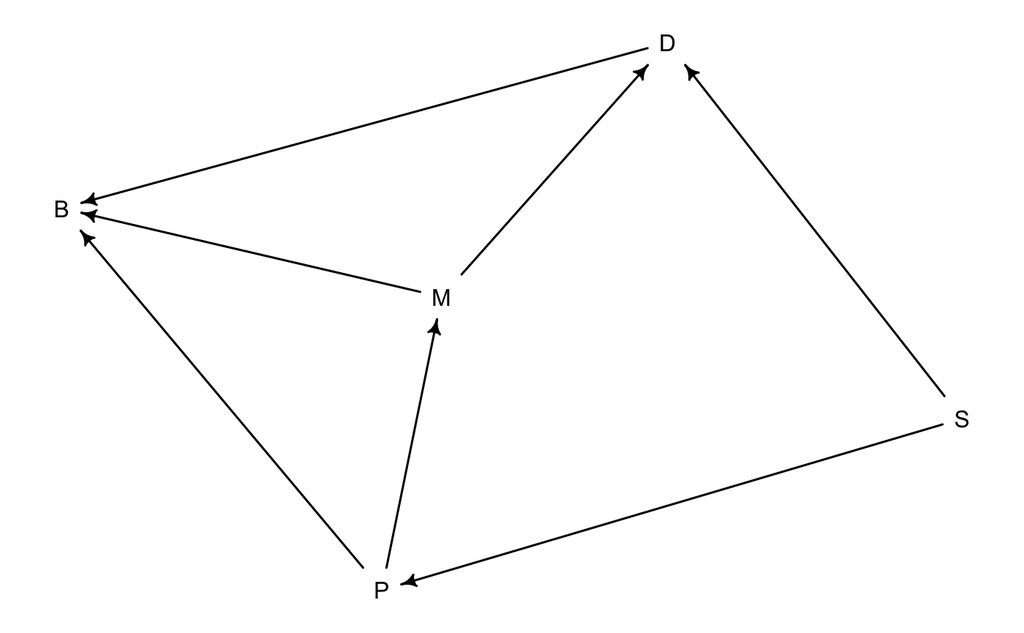

## Task 2: The data

- **Simulate some data that fits the DAG.** There are many ways to do this. A simple way is just to sample one variable from a normal distribution which has another variable as mean. McElreath does this in the book a few times, and you can use this as inspiration.

### Simulate data

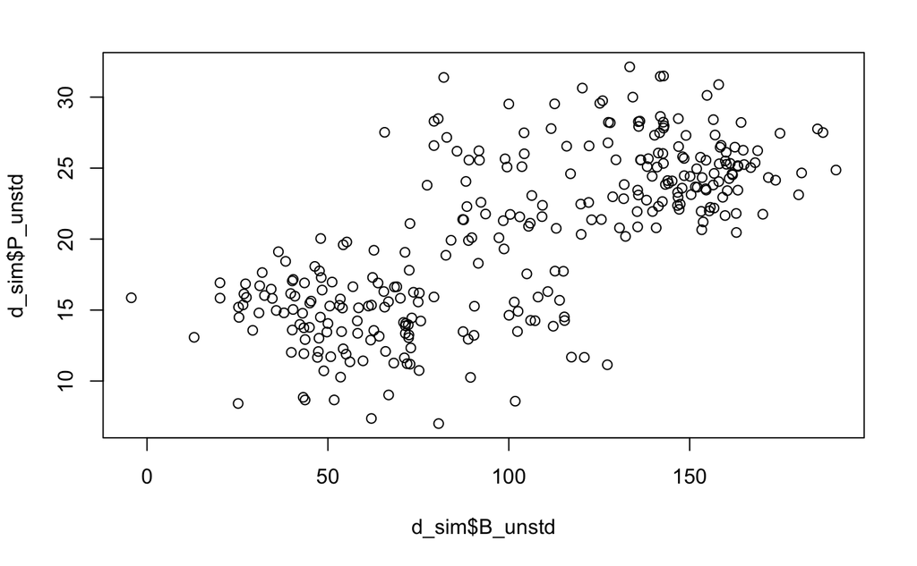